# 05 - Novel producer discoveries

## Overview

This notebook identifies plant foods that are novel producers of known natural products—compounds detected in plant species where they have not been previously reported in natural products databases.

## Background

Natural products databases like LOTUS, COCONUT, and SuperNatural 3 catalog which plant species produce which compounds. By comparing PTFI detections against these databases at the genus level, we can identify potential novel producers: food plants that contain compounds not previously associated with their genus.

## Input data

**`ptfi_data_long.csv`** - PTFI features in long format

- `sample_id`, `sample_foodon_leaf_name`, `element_id`, `element_name`, `intensity`

**`natural_products_species_consolidated.tsv`** - Known producer species from databases

- `element_id`: Metabolite identifier
- `element_name`: Compound name
- `inchi_key`: InChI key
- `species_info`: Pipe-separated list of known producer species
- `source`: Database sources (LOTUS, COCONUT, SP3)

**`ptfi_metadata.csv`** - Sample metadata

- `sample_id`, `specimen_organism_name`, `foodon_level1_name`

**`ptfi_external_db_matches.csv`** - External database matches

- Used to identify pharmaceutical compounds for additional analysis

## Outputs

1. Bar plot: Top 10 novel producers by compound class
2. Violin plots: Distribution of 4 selected compounds with novel vs. known producers highlighted

```python
import pandas as pd
import numpy as np
import matplotlib.pyplot as plt
import seaborn as sns

# Load data
ptfi_long_df = pd.read_csv("ptfi_data_long.csv")
annotated_species = pd.read_csv("natural_products_species_consolidated.tsv", sep="\t")
metadata = pd.read_csv("ptfi_metadata.csv")
external_matches = pd.read_csv("ptfi_external_db_matches.csv")

print(f"Loaded {len(ptfi_long_df)} PTFI features")
print(f"Loaded {len(annotated_species)} annotated compounds with known producers")
annotated_species.head()
```

```
Loaded 9814700 PTFI features
Loaded 514 annotated compounds with known producers
```

|  | element_id | element_name | inchi_key | species_info | source |
| --- | --- | --- | --- | --- | --- |
| 0 | MET_AEDDIBAIWPIIBD-ZJKJAXBQSA-N | Mangiferin | AEDDIBAIWPIIBD-ZJKJAXBQSA-N | Cyclopia sessiliflora\|Cyclopia genistoides\|Cyc... | COCONUT + LOTUS + SP3 |
| 1 | MET_AEQDJSLRWYMAQI-UHFFFAOYSA-N | NP-001740 | AEQDJSLRWYMAQI-UHFFFAOYSA-N | Corydalis turtschaninovii\|Stephania venosa\|Ech... | LOTUS + SP3 |
| 2 | MET_AHTRGGWSBFOEEG-BXDNVMCDSA-N | NP-001314 | AHTRGGWSBFOEEG-BXDNVMCDSA-N | Fraxinus excelsior\|Fraxinus excelsior\|Fraxinus... | COCONUT + SP3 |
| 3 | MET_AIONOLUJZLIMTK-AWEZNQCLSA-N | Hesperetin | AIONOLUJZLIMTK-AWEZNQCLSA-N | Citrus maxima\|Citrus trifoliata\|Citrus reticul... | COCONUT + LOTUS + SP3 |
| 4 | MET_AKEUNCKRJATALU-UHFFFAOYSA-N | 2,6-Dihydroxybenzoic acid | AKEUNCKRJATALU-UHFFFAOYSA-N | Alangium platanifolium\|Aniba riparia\|Fallopia ... | COCONUT + LOTUS |

## Data preparation

Filter for compounds with known producer species and merge with PTFI data.

```python
# Get list of compounds with known producer information
annotated_species_features = annotated_species["element_id"]

# Filter PTFI data for these compounds
ptfi_species = ptfi_long_df[ptfi_long_df["element_id"].isin(annotated_species_features)].copy()

# Merge with metadata to get organism names
ptfi_species = ptfi_species.merge(
    metadata[["sample_id", "specimen_organism_name", "foodon_level1_name"]],
    on="sample_id"
)

# Filter for valid scientific names (two-word format: Genus species)
ptfi_species = ptfi_species.dropna(subset=['specimen_organism_name'])
two_word_mask = ptfi_species['specimen_organism_name'].str.split().str.len() == 2
ptfi_species = ptfi_species[two_word_mask]

# Extract genus (first word of scientific name)
ptfi_species["family"] = ptfi_species["specimen_organism_name"].str.split(" ").str[0]

# Remove non-detections
ptfi_species = ptfi_species[ptfi_species['intensity'] > 0].copy()

print(f"Filtered to {len(ptfi_species)} detections with valid scientific names")
ptfi_species.head()
```

```
Filtered to 10825 detections with valid scientific names
```

|  | sample_id | sample_foodon_leaf_name | metabolite | intensity | element_id | element_name | specimen_organism_name | foodon_level1_name | family |
| --- | --- | --- | --- | --- | --- | --- | --- | --- | --- |
| 21 | GGB100030 | carrot (peeled) | MET_AEDDIBAIWPIIBD-ZJKJAXBQSA-N | 11994.201343 | MET_AEDDIBAIWPIIBD-ZJKJAXBQSA-N | Mangiferin | Daucus carota | plant food product | Daucus |
| 58 | GGB100071 | green bean pod (raw) | MET_AEDDIBAIWPIIBD-ZJKJAXBQSA-N | 1712.695698 | MET_AEDDIBAIWPIIBD-ZJKJAXBQSA-N | Mangiferin | Phaseolus vulgaris | plant food product | Phaseolus |
| 69 | GGB100084 | canary bean (raw) | MET_AEDDIBAIWPIIBD-ZJKJAXBQSA-N | 7240.750543 | MET_AEDDIBAIWPIIBD-ZJKJAXBQSA-N | Mangiferin | Phaseolus vulgaris | plant food product | Phaseolus |
| 252 | GGB100435 | cowpea (raw) | MET_AEDDIBAIWPIIBD-ZJKJAXBQSA-N | 17348.672837 | MET_AEDDIBAIWPIIBD-ZJKJAXBQSA-N | Mangiferin | Vigna unguiculata | plant food product | Vigna |
| 254 | GGB100437 | cowpea (raw) | MET_AEDDIBAIWPIIBD-ZJKJAXBQSA-N | 34897.362350 | MET_AEDDIBAIWPIIBD-ZJKJAXBQSA-N | Mangiferin | Vigna unguiculata | plant food product | Vigna |

## Identify novel producers

Compare detected genus against known producer genera from databases.

```python
def get_valid_species_set(species_string):
    """
    Extract valid species names (two-word format) from pipe-delimited string.
    """
    if pd.isna(species_string):
        return set()

    valid_species = set()
    # Clean up spacing around pipes
    species_string = species_string.replace(' | ', '|').replace('| ', '|').replace(' |', '|')

    for name in str(species_string).split('|'):
        name_clean = name.strip()
        if len(name_clean.split()) == 2:
            valid_species.add(name_clean)
    return valid_species


# Create mapping of compound to known producer genera
producer_map = annotated_species.set_index('element_id')['species_info'].apply(get_valid_species_set).to_dict()

# Extract just the genus (first word) from each species name
genus_producer_map = {
    key: {name.split()[0] for name in names}
    for key, names in producer_map.items()
}

# Add known producer genera to dataframe
ptfi_species['known_producer_genera'] = ptfi_species['element_id'].map(genus_producer_map)

print("Example of known producers:")
ptfi_species[['element_id', 'element_name', 'family', 'known_producer_genera']].head()
```

```
Example of known producers:
```

|  | element_id | element_name | family | known_producer_genera |
| --- | --- | --- | --- | --- |
| 21 | MET_AEDDIBAIWPIIBD-ZJKJAXBQSA-N | Mangiferin | Daucus | {Acystopteris, Gentianella, Tripterospermum, A... |
| 58 | MET_AEDDIBAIWPIIBD-ZJKJAXBQSA-N | Mangiferin | Phaseolus | {Acystopteris, Gentianella, Tripterospermum, A... |
| 69 | MET_AEDDIBAIWPIIBD-ZJKJAXBQSA-N | Mangiferin | Phaseolus | {Acystopteris, Gentianella, Tripterospermum, A... |
| 252 | MET_AEDDIBAIWPIIBD-ZJKJAXBQSA-N | Mangiferin | Vigna | {Acystopteris, Gentianella, Tripterospermum, A... |
| 254 | MET_AEDDIBAIWPIIBD-ZJKJAXBQSA-N | Mangiferin | Vigna | {Acystopteris, Gentianella, Tripterospermum, A... |

```python
def is_novel_producer(row):
    """
    Check if the detected genus is NOT in the list of known producers.
    """
    return row['family'] not in row['known_producer_genera']


# Identify novel hits
novel_hits_mask = ptfi_species.apply(is_novel_producer, axis=1)
novel_hits_df = ptfi_species[novel_hits_mask].copy()

# Focus on plant food products
plant_df = novel_hits_df[novel_hits_df["foodon_level1_name"] == "plant food product"]

print(f"Found {len(plant_df)} novel producer detections in plant foods")
print(f"Unique compounds: {plant_df['element_id'].nunique()}")
print(f"Unique plant species: {plant_df['specimen_organism_name'].nunique()}")
```

```
Found 7394 novel producer detections in plant foods
Unique compounds: 352
Unique plant species: 106
```

## Figure 1: Top novel producers by compound class

Identify top 10 plant species with most novel compound discoveries, colored by chemical class.

```python
# Subset for compounds that also matched DrugBank (pharmaceutical relevance)
drug_matches = external_matches[
    (external_matches["drugbank"] == True) |
    (external_matches["pubchem_drug"] == True)
]["element_id"]

plant_df_drugs = plant_df[plant_df["element_id"].isin(drug_matches)].copy()

print(f"Novel producers with pharmaceutical matches: {len(plant_df_drugs)}")
print(f"Unique genus-compound pairs: {plant_df_drugs[['specimen_organism_name', 'element_id']].drop_duplicates().shape[0]}")
```

```
Novel producers with pharmaceutical matches: 1495
Unique genus-compound pairs: 776
```

```python
# Calculate presence percentage across all samples
def calculate_presence_percentage_long(df, metabolite_list):
    """
    Calculate percentage of samples where each metabolite is present.
    """
    metabolites_to_check = [met for met in metabolite_list if met in df['element_id'].values]

    if not metabolites_to_check:
        print("None of the provided metabolites were found in the DataFrame.")
        return pd.Series(dtype=float)

    df_filtered = df[df['element_id'].isin(metabolites_to_check)]
    presence_counts = df_filtered[df_filtered['intensity'] > 0].groupby('element_id')['sample_id'].nunique()
    total_samples = df['sample_id'].nunique()
    presence_percentage = (presence_counts / total_samples) * 100
    presence_percentage = presence_percentage.reindex(metabolites_to_check, fill_value=0)

    return presence_percentage.sort_values(ascending=False)


# Filter for compounds present in ≤10% of samples (rare compounds)
metabolite_list = plant_df_drugs["element_id"].unique()
percentages = calculate_presence_percentage_long(ptfi_long_df, metabolite_list)
filtered_compounds = percentages[percentages <= 10].index.tolist()

plot_data = plant_df_drugs[plant_df_drugs["element_id"].isin(filtered_compounds)].copy()

print(f"Compounds present in ≤10% of samples: {len(filtered_compounds)}")
print(f"Novel producer detections for plotting: {len(plot_data)}")
```

```
Compounds present in ≤10% of samples: 54
Novel producer detections for plotting: 347
```

```python
# Add ClassyFire classifications
plot_data["inchikey"] = plot_data["element_id"].str.replace("MET_", "")
classyfire = pd.read_csv('classyfire_20250917154117.csv')
plot_data = plot_data.merge(classyfire, left_on="inchikey", right_on="InChIKey", how="left")

# Add common food names
plot_data = plot_data.merge(
    metadata[["sample_id", "specimen_food_product_name"]],
    on="sample_id"
)

# Standardize some common food names
name_standardization = {
    "soy milk": "Soybean",
    "edamame": "Soybean",
    "Carrot Reference Food": "Carrot",
    "tomato": "Tomato",
    "cowpea": "Cowpea",
    "brown lentils": "Brown lentils",
    "okra": "Okra"
}

for old_name, new_name in name_standardization.items():
    plot_data.loc[plot_data["specimen_food_product_name"] == old_name, "specimen_food_product_name"] = new_name

plot_data.head()
```

|  | sample_id | sample_foodon_leaf_name | metabolite | intensity | element_id | element_name | specimen_organism_name | foodon_level1_name | family | known_producer_genera | ... | ClassyFy Status | Kingdom | Superclass | Class | Subclass | Parent Level 1 | Parent Level 2 | Parent Level 3 | Parent Level 4 | specimen_food_product_name |
| --- | --- | --- | --- | --- | --- | --- | --- | --- | --- | --- | --- | --- | --- | --- | --- | --- | --- | --- | --- | --- | --- |
| 0 | GGB100030 | carrot (peeled) | MET_AIONOLUJZLIMTK-AWEZNQCLSA-N | 6759.249887 | MET_AIONOLUJZLIMTK-AWEZNQCLSA-N | Hesperetin | Daucus carota | plant food product | Daucus | {Solanum, Allium, Dalbergia, Camellia, Brickel... | ... | Completed | Organic compounds | Phenylpropanoids and polyketides | Flavonoids | O-methylated flavonoids | 4'-O-methylated flavonoids | NaN | NaN | NaN | Carrot |
| 1 | GGB100648 | carrot (peeled) | MET_AIONOLUJZLIMTK-AWEZNQCLSA-N | 4694.582993 | MET_AIONOLUJZLIMTK-AWEZNQCLSA-N | Hesperetin | Daucus carota | plant food product | Daucus | {Solanum, Allium, Dalbergia, Camellia, Brickel... | ... | Completed | Organic compounds | Phenylpropanoids and polyketides | Flavonoids | O-methylated flavonoids | 4'-O-methylated flavonoids | NaN | NaN | NaN | Carrot |
| 2 | GGB101565 | carrot (peeled) | MET_AIONOLUJZLIMTK-AWEZNQCLSA-N | 1574.338066 | MET_AIONOLUJZLIMTK-AWEZNQCLSA-N | Hesperetin | Daucus carota | plant food product | Daucus | {Solanum, Allium, Dalbergia, Camellia, Brickel... | ... | Completed | Organic compounds | Phenylpropanoids and polyketides | Flavonoids | O-methylated flavonoids | 4'-O-methylated flavonoids | NaN | NaN | NaN | carrot |
| 3 | GGB101566 | carrot (peeled) | MET_AIONOLUJZLIMTK-AWEZNQCLSA-N | 1148.494349 | MET_AIONOLUJZLIMTK-AWEZNQCLSA-N | Hesperetin | Daucus carota | plant food product | Daucus | {Solanum, Allium, Dalbergia, Camellia, Brickel... | ... | Completed | Organic compounds | Phenylpropanoids and polyketides | Flavonoids | O-methylated flavonoids | 4'-O-methylated flavonoids | NaN | NaN | NaN | carrot |
| 4 | GGB101567 | carrot (peeled) | MET_AIONOLUJZLIMTK-AWEZNQCLSA-N | 2844.931352 | MET_AIONOLUJZLIMTK-AWEZNQCLSA-N | Hesperetin | Daucus carota | plant food product | Daucus | {Solanum, Allium, Dalbergia, Camellia, Brickel... | ... | Completed | Organic compounds | Phenylpropanoids and polyketides | Flavonoids | O-methylated flavonoids | 4'-O-methylated flavonoids | NaN | NaN | NaN | carrot |

5 rows × 22 columns

```python
def plot_composition_with_common_names(
    merged_df,
    top_n=10,
    species_col='specimen_organism_name',
    common_name_col='specimen_foodon_leaf_name',
    category_col='class',
    output_filename="composition_class.pdf",
    fig_size=(18, 7),
    fontscale=1.2,
    dpi=300
):
    """
    Creates a full-width stacked bar chart with the common name annotated below each bar.
    Legend is placed in two columns inside the plot area (top right corner).
    """

    # 1. Create a lookup map from scientific name to common name
    common_name_map = merged_df.drop_duplicates(subset=[species_col])
    common_name_map = common_name_map.set_index(species_col)[common_name_col]

    # 2. Count discoveries per species and per chemical class
    composition_counts = merged_df.groupby([species_col, category_col]).size().unstack(fill_value=0)

    # 3. Find and sort the top N species
    composition_counts['total'] = composition_counts.sum(axis=1)
    top_species_composition = composition_counts.nlargest(top_n, 'total')
    top_species_composition = top_species_composition.sort_values(by='total', ascending=False)

    # 4. Remove the 'total' column for plotting
    plot_data = top_species_composition.drop(columns='total')

    # 5. Remove classes with zero counts across all top species
    plot_data = plot_data.loc[:, (plot_data.sum(axis=0) > 0)]

    # 6. Generate the plot
    sns.set_theme(style="white")
    sns.set_context("paper")
    sns.set(font_scale=fontscale)

    fig, ax = plt.subplots(figsize=fig_size, facecolor='white')

    plot_data.plot(
        kind='bar',
        stacked=True,
        ax=ax,
        cmap='tab20'
    )

    # Set white background
    ax.set_facecolor('white')
    fig.patch.set_facecolor('white')

    # 7. Add axis spines (borders)
    ax.spines['left'].set_visible(True)
    ax.spines['left'].set_linewidth(1.5)
    ax.spines['left'].set_color('black')

    ax.spines['bottom'].set_visible(True)
    ax.spines['bottom'].set_linewidth(1.5)
    ax.spines['bottom'].set_color('black')

    ax.spines['top'].set_visible(False)
    ax.spines['right'].set_visible(False)

    # 8. Create custom x-tick labels
    xtick_labels = []
    for i, species_name in enumerate(plot_data.index):
        common_name = common_name_map.get(species_name, '')
        species_formatted = species_name.replace(' ', r'\ ')

        if common_name:
            label = f"$\it{{{species_formatted}}}$\n({common_name})"
        else:
            label = f"$\it{{{species_formatted}}}$"

        xtick_labels.append(label)

    ax.set_xticklabels(xtick_labels, rotation=90, ha='right', fontsize=14)
    ax.set_ylim(top=ax.get_ylim()[1] * 1.15)

    # 9. Formatting
    ax.set_ylabel('Number of Novel Compounds', fontsize=16)
    ax.set_xlabel('', fontsize=14)

    # Make tick marks visible and adjust size
    ax.tick_params(axis='both', which='major', labelsize=16, width=1.5, length=6)

    ax.legend(
        title=category_col.title(),
        bbox_to_anchor=(0.98, 0.98),
        loc='upper right',
        ncol=2,
        fontsize=14,
        title_fontsize=15,
        frameon=True,
        fancybox=False,
        edgecolor='black',
        framealpha=0.95
    )

    plt.tight_layout(rect=[0, 0, 1, 1])
    ax.grid(False)

    # 10. Save as PDF
    import os
    save_dir = os.path.dirname(output_filename)
    if save_dir and not os.path.exists(save_dir):
        os.makedirs(save_dir)

    plt.savefig(output_filename, format='pdf', dpi=dpi, bbox_inches='tight', facecolor='white')
    print(f"Plot saved to: {output_filename}")

    plt.show()
```

```
Plot saved to: composition_class.pdf
```

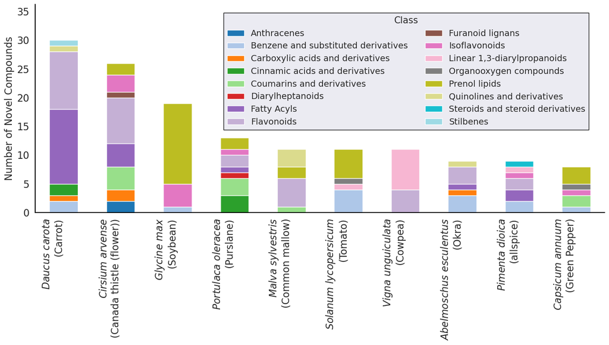

```python
# Create bar plot
plot_composition_with_common_names(
    plot_data,
    top_n=10,
    category_col="Class",
    common_name_col="specimen_food_product_name",
    fig_size=(14, 8),
    fontscale=1
)
```

## Figure 2: Violin plots for selected compounds

Compare intensity distributions for 4 compounds, highlighting novel vs. known producers.

```python
def create_single_violin_plot_with_producers(
    metabolite_df,
    highlights,
    met_name,
    figsize=(4, 4),
    dpi=300,
    log_transform=True
):
    """
    Create violin plot showing metabolite distribution with highlighted samples.

    Parameters:
    -----------
    metabolite_df : DataFrame
        All metabolite intensity data
    highlights : DataFrame
        Specific samples to highlight (novel vs. known producers)
    met_name : str
        Compound name for labeling
    figsize : tuple
        Figure dimensions
    dpi : int
        Resolution
    log_transform : bool
        Whether to log-transform intensities
    """
    fig, ax = plt.subplots(figsize=figsize, dpi=dpi)

    # Set font sizes
    plt.rcParams.update({
        'font.size': 10,
        'axes.labelsize': 9,
        'axes.titlesize': 9,
        'xtick.labelsize': 8,
        'ytick.labelsize': 8,
        'legend.fontsize': 6,
        'legend.title_fontsize': 8
    })

    # Log transform if requested
    if log_transform:
        metabolite_df = metabolite_df.copy()
        highlights = highlights.copy()
        metabolite_df["intensity"] = np.log10(metabolite_df["intensity"] + 1)
        highlights["intensity"] = np.log10(highlights["intensity"] + 1)

    # Create violin plot
    violin_parts = ax.violinplot(
        [metabolite_df['intensity'].values],
        positions=[0],
        showmeans=False,
        showmedians=False,
        showextrema=True,
        widths=0.8
    )

    # Style violin
    for pc in violin_parts['bodies']:
        pc.set_facecolor('lightgray')
        pc.set_alpha(0.6)
        pc.set_edgecolor('darkgray')
        pc.set_linewidth(1.5)

    violin_parts['cbars'].set_color('gray')
    violin_parts['cmins'].set_color('gray')
    violin_parts['cmaxes'].set_color('gray')

    # Add boxplot overlay
    box_parts = ax.boxplot(
        metabolite_df['intensity'].values,
        positions=[0],
        widths=0.3,
        patch_artist=True,
        showfliers=False,
        medianprops={'color': 'black', 'linewidth': 1},
        boxprops={'facecolor': 'white', 'alpha': 0.8, 'edgecolor': 'black'},
        whiskerprops={'color': 'black', 'linewidth': 1.5},
        capprops={'color': 'black', 'linewidth': 1.5}
    )

    # Define colors for producers
    unique_producers = highlights['sample_foodon_leaf_name'].unique()
    colorblind_colors = ['#1f77b4', '#ff7f0e', '#2ca02c', '#d62728', '#9467bd',
                        '#8c564b', '#e377c2', '#7f7f7f', '#bcbd22', '#17becf']
    colors = colorblind_colors[:len(unique_producers)]
    producer_colors = dict(zip(unique_producers, colors))

    # Define markers
    marker_dict = {'novel': '^', 'known': 'o'}
    marker_size_dict = {'novel': 25, 'known': 20}

    # Plot highlighted points
    for _, row in highlights.iterrows():
        producer = row['sample_foodon_leaf_name']
        novel_known = row['novel_known']
        y_pos = row['intensity']

        color = producer_colors[producer]
        marker = marker_dict[novel_known]
        size = marker_size_dict[novel_known]

        jitter = np.random.normal(0, 0.05)
        ax.scatter(
            0 + jitter, y_pos,
            color=color, s=size, alpha=0.9,
            marker=marker,
            edgecolors='black', linewidth=0.5, zorder=5
        )

    # Formatting
    ax.set_xlim(-0.5, 0.5)
    ax.set_xticks([0])
    ax.set_xticklabels("")
    ax.set_xlabel(f'{met_name} distribution', fontweight='normal')
    ax.set_ylabel('Intensity (log₁₀)', fontweight='normal')

    # Create legends
    producer_legend_elements = []
    for producer in unique_producers:
        producer_legend_elements.append(
            plt.Line2D([0], [0], marker='s', color='w',
                      markerfacecolor=producer_colors[producer],
                      markersize=9, label=producer,
                      markeredgecolor='black', markeredgewidth=0.5)
        )

    shape_legend_elements = [
        plt.Line2D([0], [0], marker='^', color='w', markerfacecolor='gray',
                  markersize=6, label='Novel',
                  markeredgecolor='black', markeredgewidth=0.5),
        plt.Line2D([0], [0], marker='o', color='w', markerfacecolor='gray',
                  markersize=6, label='Known',
                  markeredgecolor='black', markeredgewidth=0.5)
    ]

    # Position legends
    legend1 = ax.legend(
        handles=producer_legend_elements, title='Producer',
        loc='upper center', bbox_to_anchor=(0.30, 1.30),
        frameon=True, fancybox=False, shadow=False,
        borderpad=0.3, handletextpad=0.3, columnspacing=0.5, ncol=2
    )

    legend2 = ax.legend(
        handles=shape_legend_elements, title='Type',
        loc='upper center', bbox_to_anchor=(0.85, 1.30),
        frameon=True, fancybox=False, shadow=False,
        borderpad=0.3, handletextpad=0.3, columnspacing=0.5
    )

    ax.add_artist(legend1)

    # Grid and spines
    ax.grid(True, alpha=0.2, linestyle='-', linewidth=0.5, axis='y')
    ax.spines['top'].set_visible(False)
    ax.spines['right'].set_visible(False)
    ax.spines['left'].set_linewidth(0.8)
    ax.spines['bottom'].set_linewidth(0.8)

    plt.tight_layout()
    fig.subplots_adjust(top=0.85)

    return fig, ax
```

```
Creating violin plot for Biochanin A...
```

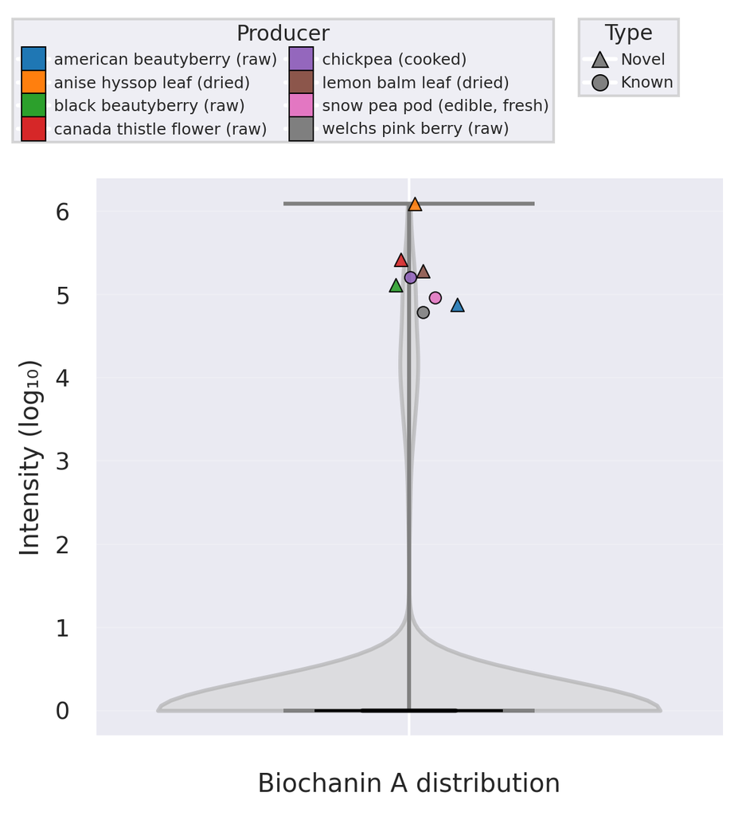

```
Creating violin plot for Chrysin...
```

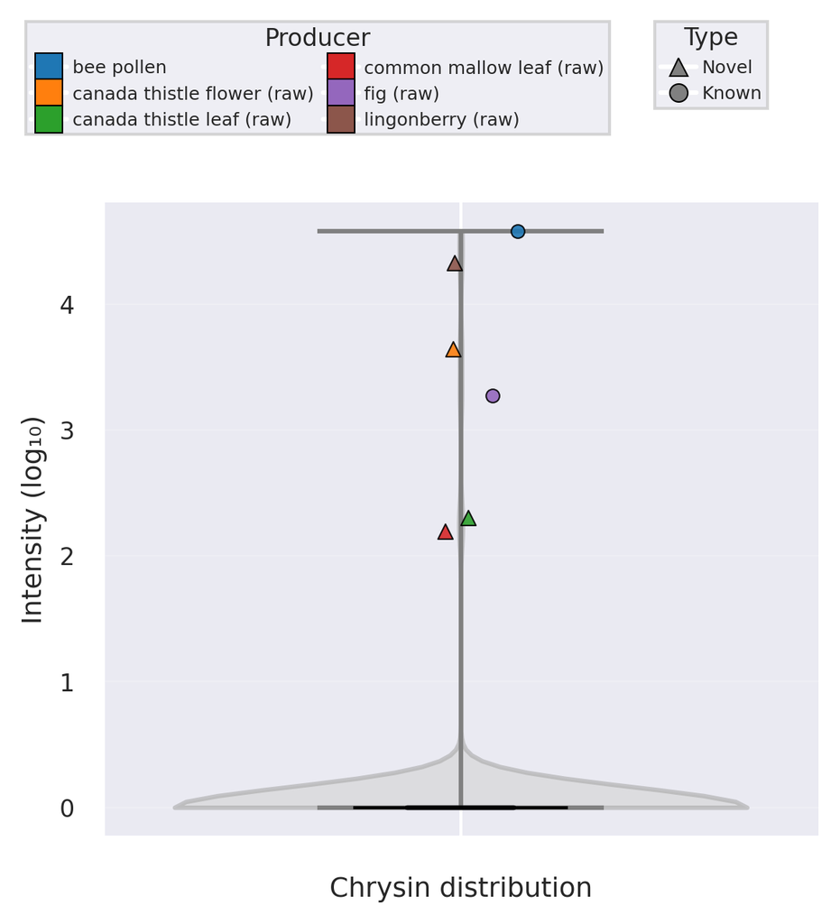

```
Creating violin plot for Isoliquiritigenin...
```

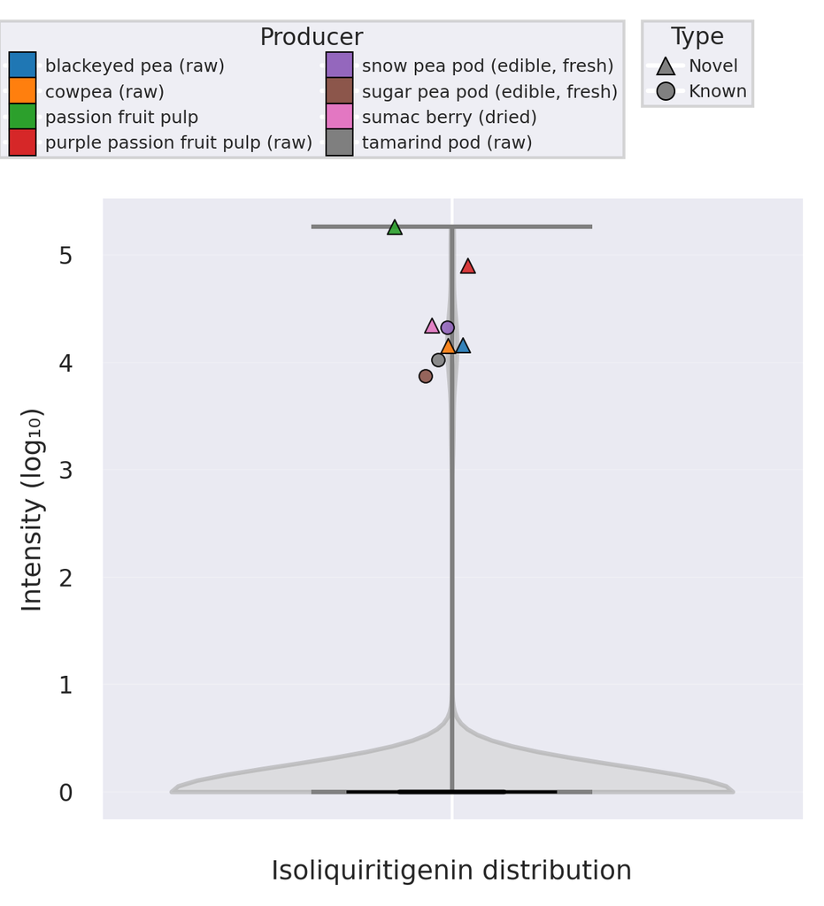

```
Creating violin plot for Tiliroside...
```

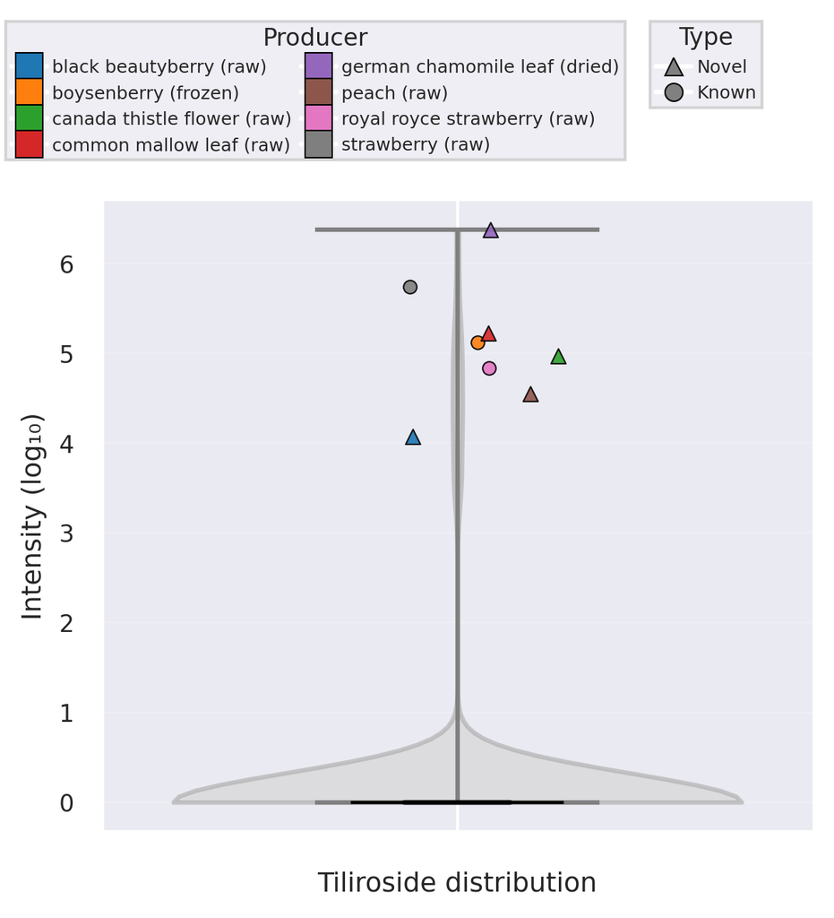

```python
# Compounds to visualize
compounds_to_plot = ['Biochanin A', 'Chrysin', 'Isoliquiritigenin', 'Tiliroside']

sns.set(font_scale=0.8)

for METABOLITE_TO_PLOT in compounds_to_plot:
    print(f"\nCreating violin plot for {METABOLITE_TO_PLOT}...")

    # Get all intensity data for this compound
    metabolite_df = ptfi_long_df[ptfi_long_df["element_name"] == METABOLITE_TO_PLOT]
    metabolite_df = metabolite_df.groupby(
        ["element_name", "sample_foodon_leaf_name"]
    )["intensity"].mean().reset_index()

    # Find top 5 novel producers
    top_5_novel = plant_df.groupby(
        ['element_name', 'sample_foodon_leaf_name']
    )['intensity'].mean().reset_index()
    top_5_novel = top_5_novel[top_5_novel["intensity"] > 0]
    top_5_novel = top_5_novel[
        top_5_novel['element_name'] == METABOLITE_TO_PLOT
    ].sort_values("intensity", ascending=False).head(5)

    NOVEL_SAMPLES = list(top_5_novel['sample_foodon_leaf_name'])

    # Find top 3 known (benchmark) producers
    top_3_known = metabolite_df[
        ~metabolite_df['sample_foodon_leaf_name'].isin(NOVEL_SAMPLES)
    ]
    top_3_known = top_3_known[top_3_known["intensity"] > 0]
    top_3_known = top_3_known.sort_values("intensity", ascending=False).head(3)

    BENCHMARK_SAMPLES = list(top_3_known['sample_foodon_leaf_name'])

    # Combine highlighted samples
    ALL_HIGHLIGHTED = NOVEL_SAMPLES + BENCHMARK_SAMPLES

    highlight_df = metabolite_df[
        metabolite_df['sample_foodon_leaf_name'].isin(ALL_HIGHLIGHTED)
    ].copy()

    highlight_df['novel_known'] = np.where(
        highlight_df['sample_foodon_leaf_name'].isin(NOVEL_SAMPLES),
        'novel',
        'known'
    )

    # Create plot
    fig, ax = create_single_violin_plot_with_producers(
        metabolite_df,
        highlight_df,
        met_name=METABOLITE_TO_PLOT,
        dpi=300,
        figsize=(4, 4)
    )

    # Save
    plt.savefig(
        f'results/{METABOLITE_TO_PLOT.replace(" ", "_")}_violin.png',
        dpi=300, bbox_inches='tight'
    )
    plt.show()
```